# P4 - Red Wine Quality - Exploratory Data Analysis by S.Jaeger

```
##   X fixed.acidity volatile.acidity citric.acid residual.sugar chlorides
## 1 1           7.4             0.70        0.00            1.9     0.076
## 2 2           7.8             0.88        0.00            2.6     0.098
## 3 3           7.8             0.76        0.04            2.3     0.092
##   free.sulfur.dioxide total.sulfur.dioxide density   pH sulphates alcohol
## 1                  11                   34  0.9978 3.51      0.56     9.4
## 2                  25                   67  0.9968 3.20      0.68     9.8
## 3                  15                   54  0.9970 3.26      0.65     9.8
##   quality
## 1       5
## 2       5
## 3       5
```

As the X variable is useless here (it is only a list of indexes of the observations), I propose to remove it.

```r
#Nulling X variable
wqr$X <- NULL
```

> **Note**: As stated in Udacity’s data option page [1], this tidy data set contains 1,599 red wines (of the Portuguese “Vinho Verde”) with 11 variables on the chemical properties of the wine. At least 3 wine experts rated the quality of each wine, providing a rating between 0 (very bad) and 10 (very excellent). This data has been collected and made available by a scientific study from [Cortez et al., 2009]. The main guiding question through my exploration of this data will be **Which chemical properties influence the quality of red wines?**

# why did I choose this dataset ?

Probably because as many French native, I love wine. I love speaking, seeing, smelling and of course tasting wine, especially when it comes associated with a good meal. However I am afraid I don’t know much about the chemical properties of wine, except may be some rumor that states that wine having a lot of sulphates might cause severe headache the day after :o). If like me you are interested in learning about wine, I just can not resist in introducing “The drops of God” by Tadashi Agi (“Les Gouttes de Dieu” in French):

[figure not shown]

This Japanese Manga is perfect to learn more about wine without getting too serious. At the end of each volume of this comic strip, the author includes an additional leaflet describing each specific wine mentioned in the story. Besides, it covers wines from all over the world. I encourage you in reading those books !

# Univariate Plots Section

> **Note**: In this section, we will explore the data focusing on a single variable.

As we are interested on how different chemical factor influence the quality of wine it sounds sensible to have a detailed look at the quality variable.

```r
#Basic statistics
summary(wqr$quality)
```

```
##    Min. 1st Qu.  Median    Mean 3rd Qu.    Max.
##   3.000   5.000   6.000   5.636   6.000   8.000
```

Wine quality ranges from 3 (Min quality) to 8 (Max quality), With first quartile at 5 & 3rd at 6.

```r
#Standard Dev.
sd(wqr$quality)
```

```
## [1] 0.8075694
```

Standard deviation is 0.8 on a scale from 3 to 8, this means that there is a low variance, and that a lot of records in a range of [-0.8, 0.8] around the mean, that is between [4.8, 6.4] (As quality is expressed as an integer, is shall rather be between [5, 6].

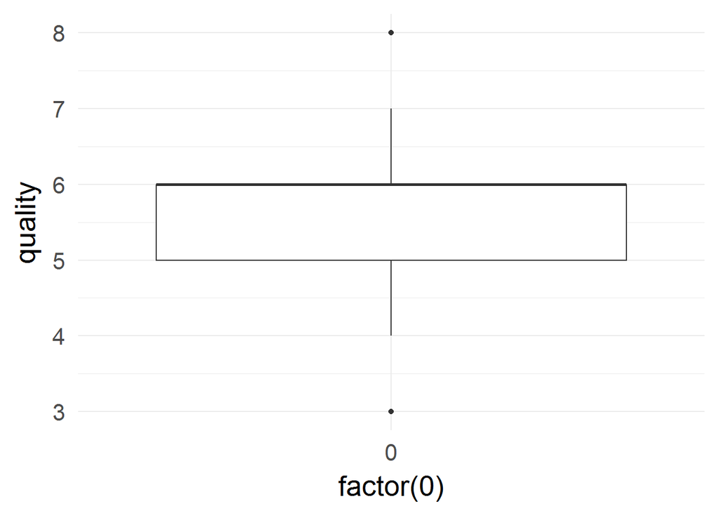

We can see that quality 3 and 8 are considered as outliers, which means that there must be very few of them.  
Let us verify all those hypothesis by looking at the distribution of wine quality: For readability, it will be more comfortable to convert the wine quality expressed as a digit between 3 & 8 as a factor.

```
## 'data.frame':    1599 obs. of  12 variables:
##  $ fixed.acidity       : num  7.4 7.8 7.8 11.2 7.4 7.4 7.9 7.3 7.8 7.5 ...
##  $ volatile.acidity    : num  0.7 0.88 0.76 0.28 0.7 0.66 0.6 0.65 0.58 0.5 ...
##  $ citric.acid         : num  0 0 0.04 0.56 0 0 0.06 0 0.02 0.36 ...
##  $ residual.sugar      : num  1.9 2.6 2.3 1.9 1.9 1.8 1.6 1.2 2 6.1 ...
##  $ chlorides           : num  0.076 0.098 0.092 0.075 0.076 0.075 0.069 0.065 0.073 0.071 ...
##  $ free.sulfur.dioxide : num  11 25 15 17 11 13 15 15 9 17 ...
##  $ total.sulfur.dioxide: num  34 67 54 60 34 40 59 21 18 102 ...
##  $ density             : num  0.998 0.997 0.997 0.998 0.998 ...
##  $ pH                  : num  3.51 3.2 3.26 3.16 3.51 3.51 3.3 3.39 3.36 3.35 ...
##  $ sulphates           : num  0.56 0.68 0.65 0.58 0.56 0.56 0.46 0.47 0.57 0.8 ...
##  $ alcohol             : num  9.4 9.8 9.8 9.8 9.4 9.4 9.4 10 9.5 10.5 ...
##  $ quality             : int  5 5 5 6 5 5 5 7 7 5 ...
```

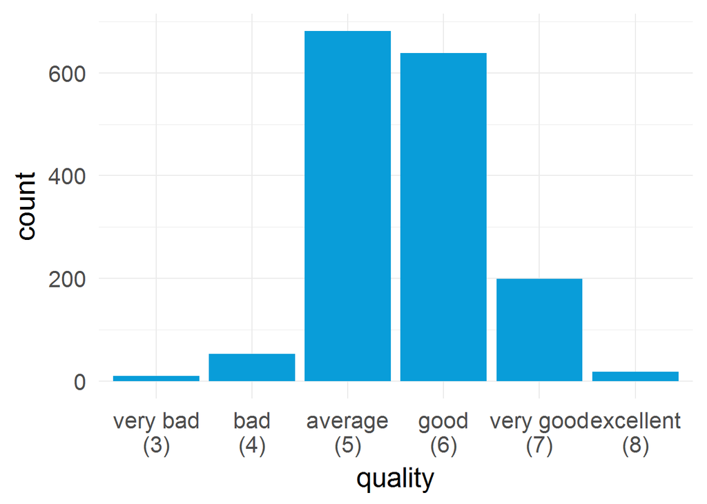

```r
#Getting histogram exact values
table(wqr$quality)
```

```
##
##  very bad\n(3)       bad\n(4)   average\n(5)      good\n(6) very good\n(7)
##             10             53            681            638            199
## excellent\n(8)
##             18
```

Let us have a look at all other variables:

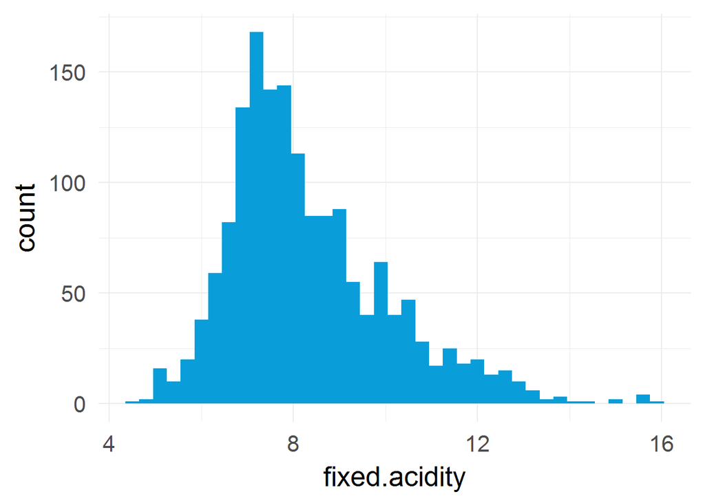

```r
#Plotting fixed acidity
qplot(x = fixed.acidity, data=wqr,fill=I('#099DD9'),binwidth=0.3)
```

Fixed.acidity has a long tailed distribution.

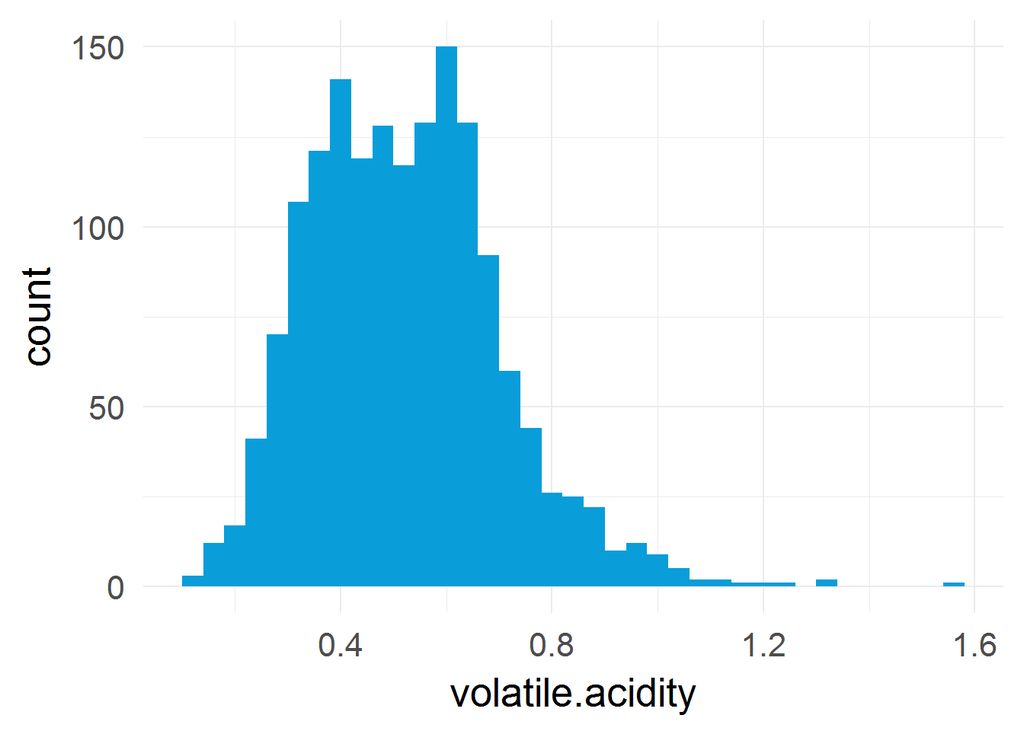

```r
#Plotting volatile acidity
qplot(x = volatile.acidity, data=wqr,fill=I('#099DD9'),binwidth=0.04)
```

Volatile.Acidity looks like a bimodal distribution.

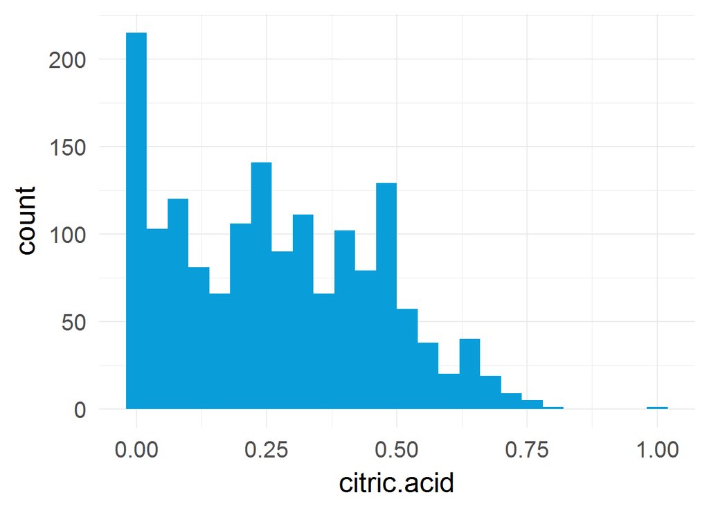

```r
#Plotting citric.acid
qplot(x = citric.acid, data=wqr,fill=I('#099DD9'),binwidth=0.04)
```

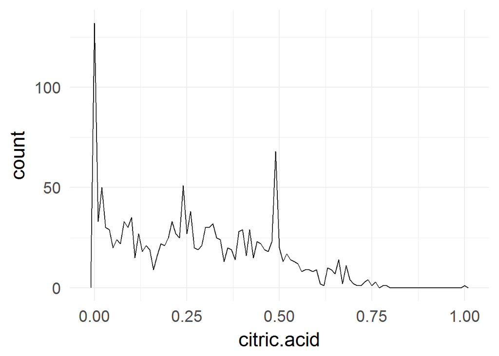

```r
#Using freqpoly to better visualize variations
qplot(x=citric.acid,data=wqr,binwidth=0.01,geom = "freqpoly")
```

Citric.acid distribution is generally decreasing with a few peaks at 0, 0.25 & 0.5.

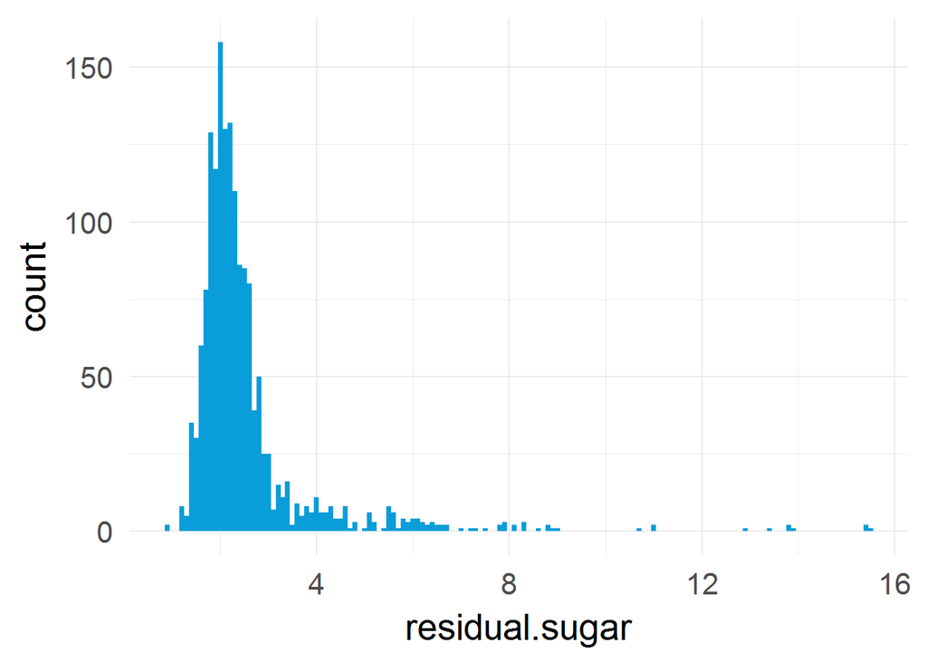

```r
#Plotting residual sugar
qplot(x = residual.sugar, data=wqr,fill=I('#099DD9'),binwidth=0.1)
```

Residual.sugar is normally distributed but skewed with a lot of outliers on the right. Let us improve this plot by removing outliers on the right.

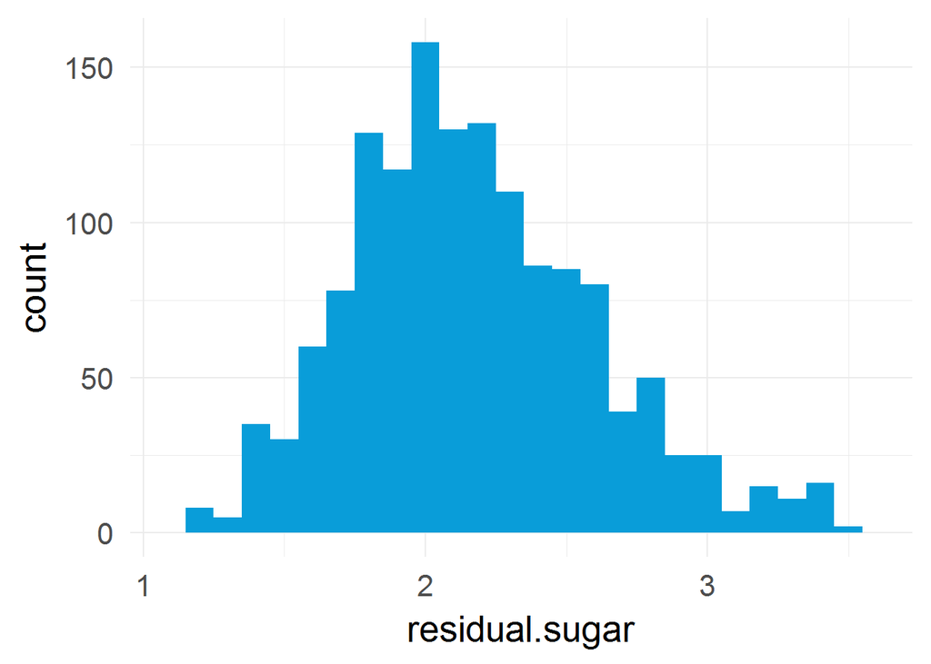

```r
#Plotting residual sugar removing 10% of outliers on the right
#and a very little on the left
ggplot(aes(x=residual.sugar, fill=I('#099DD9')), data = wqr) +
        geom_histogram(binwidth=0.1)+
  xlim(quantile(wqr$residual.sugar, 0.001),quantile(wqr$residual.sugar, 0.9))
```

The 1st plot has been used as input for the reframing of the second plot. I found it relevant to stripe the 10% outliers on the right and a very few of them on the left to retrieve a normal distribution centered around 2.

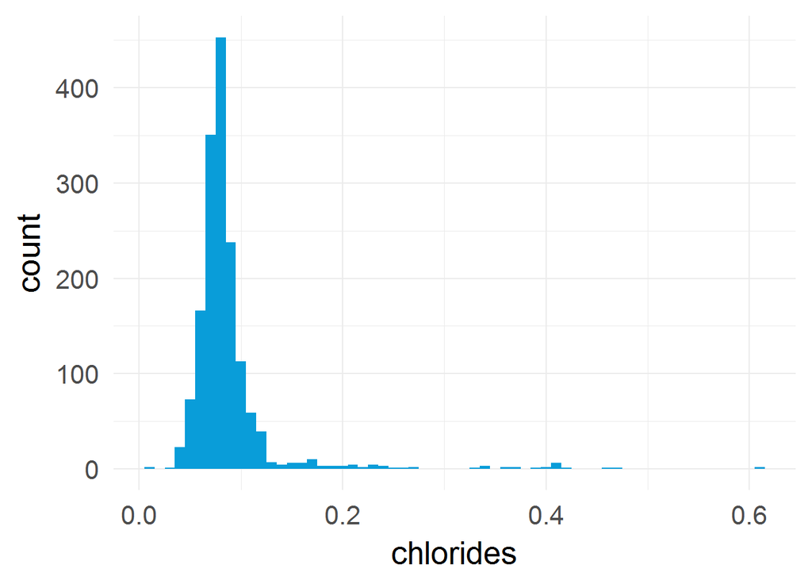

```r
#Plotting chlorides
qplot(x = chlorides, data=wqr,fill=I('#099DD9'),binwidth=0.01)
```

Chlorides are normally distributed with a lot of outliers on the right. Let us repeat previous process and remove outliers to get a better view.

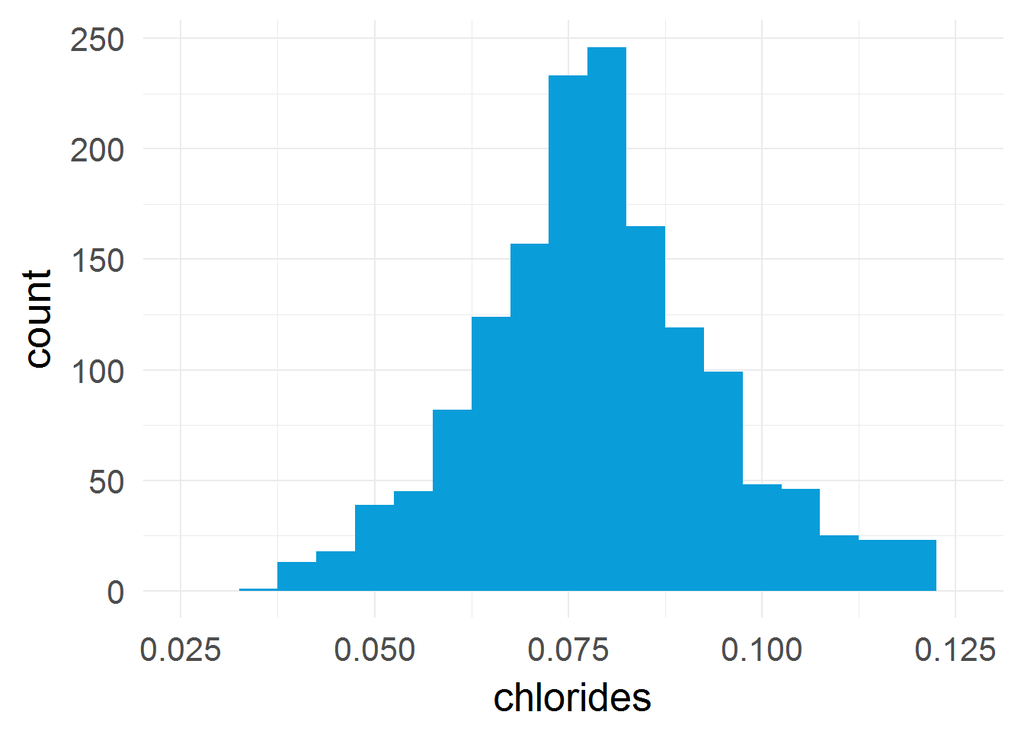

```r
#Plotting residual sugar removing 10% of outliers on the right
#and a very little on the left
ggplot(aes(x=chlorides, fill=I('#099DD9')), data = wqr) +
        geom_histogram(binwidth=0.005)+
  xlim(quantile(wqr$chlorides, 0.001),quantile(wqr$chlorides, 0.95))
```

Again, removing the outliers (5% on the right, a few ones on the left) enables to get a much better view on the distribution.

> **Note**: Although we are within the univariate section, I find relevant in this special case to overlay histograms as they are related to the same chemical properties (total & free sulfur.dioxyde). Even if one could argue that such a plot would be technically bivariate since it contains two different variables.

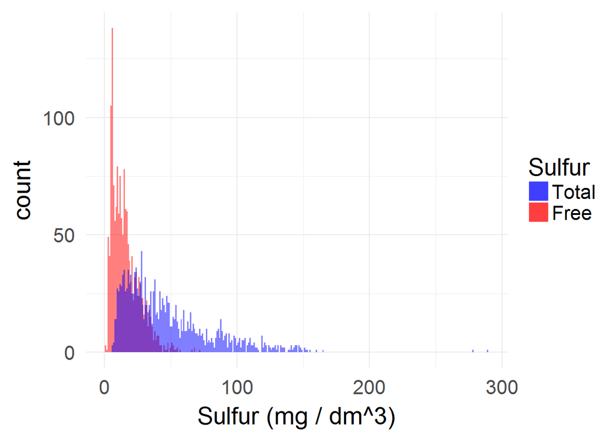

```r
#Plotting sulfur.dioxyde, overlaying total & free
ggplot(wqr)+
  geom_histogram(aes(x=free.sulfur.dioxide,fill='r'),alpha=0.5, binwidth=1)+
  geom_histogram(aes(x=total.sulfur.dioxide,fill='b'),alpha=0.5, binwidth = 1)+
  labs(x="Sulfur (mg / dm^3)")+
  scale_fill_manual(name="Sulfur", values=c("r" = "red", "b"="blue"), labels=c("b"="Total", "r"="Free"))
```

free.sulfur.dioxide & and especially total.sulfur.dioxide have almost a normal distribution but are long tailed on the right. Let us visualize them with a log10 scale to retrieve a more normal distribution.

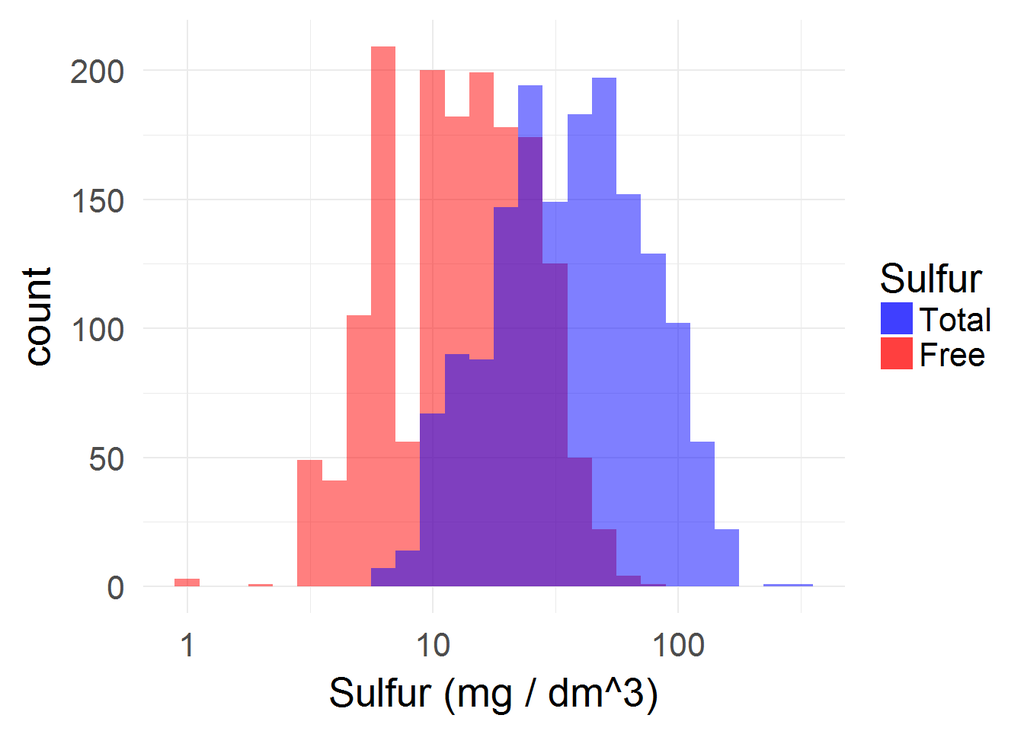

```r
#Plotting sulfur.dioxyde, overlaying total & free with log10scale
ggplot(wqr)+
  geom_histogram(aes(x=free.sulfur.dioxide,fill='r'),alpha=0.5, binwidth=.1)+
  geom_histogram(aes(x=total.sulfur.dioxide,fill='b'),alpha=0.5, binwidth = .1)+
  scale_x_log10()+
  labs(x="Sulfur (mg / dm^3)")+
  scale_fill_manual(name="Sulfur", values=c("r" = "red", "b"="blue"), labels=c("b"="Total", "r"="Free"))
```

This graph is very useful to highlight something odd that I can not explain:  
I would expect the Free quantity of Sulfure to be fully included within the Total quantity of Sulfur (attention has been paid to the measuring units that are identicals for both variables), which is not the case here. Instead, We see two normal distribution having roughly the same characteristics, but the total one being shifted on the right.

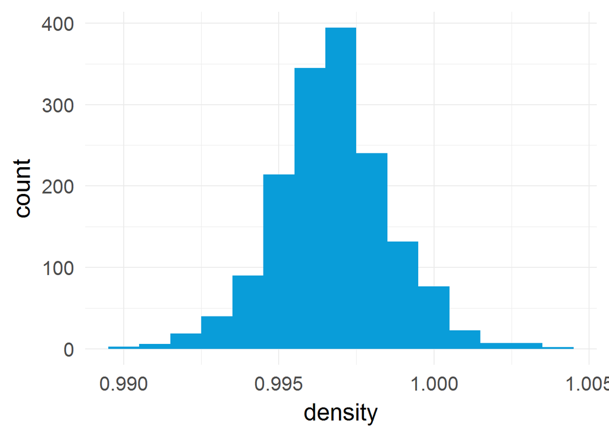

```r
#Plotting density distribution
qplot(x = density, data=wqr,fill=I('#099DD9'),binwidth=0.001)
```

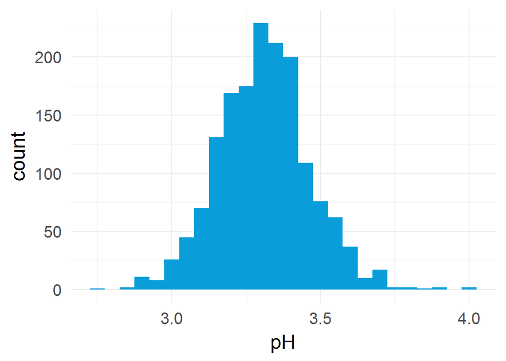

```r
#Plotting pH distribution
qplot(x = pH, data=wqr,fill=I('#099DD9'),binwidth=0.05)
```

pH has a beautiful normal distribution centered around 3.25.

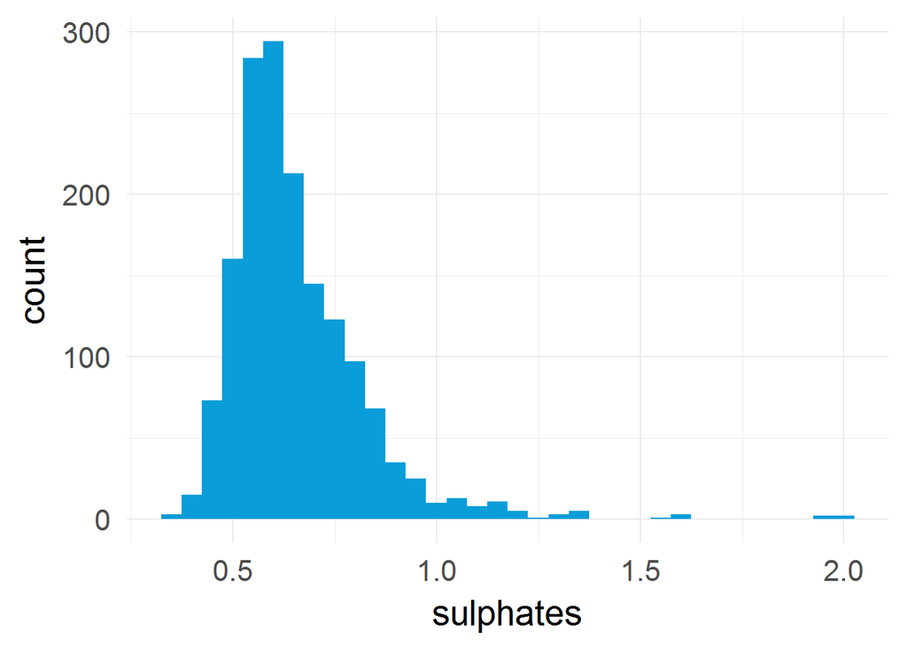

```r
#Histogram of sulphates
qplot(x = sulphates, data=wqr,fill=I('#099DD9'),binwidth=0.05)
```

Sulphates has a normal distribution centerd around 0.6 with a lot of outliers on the right.

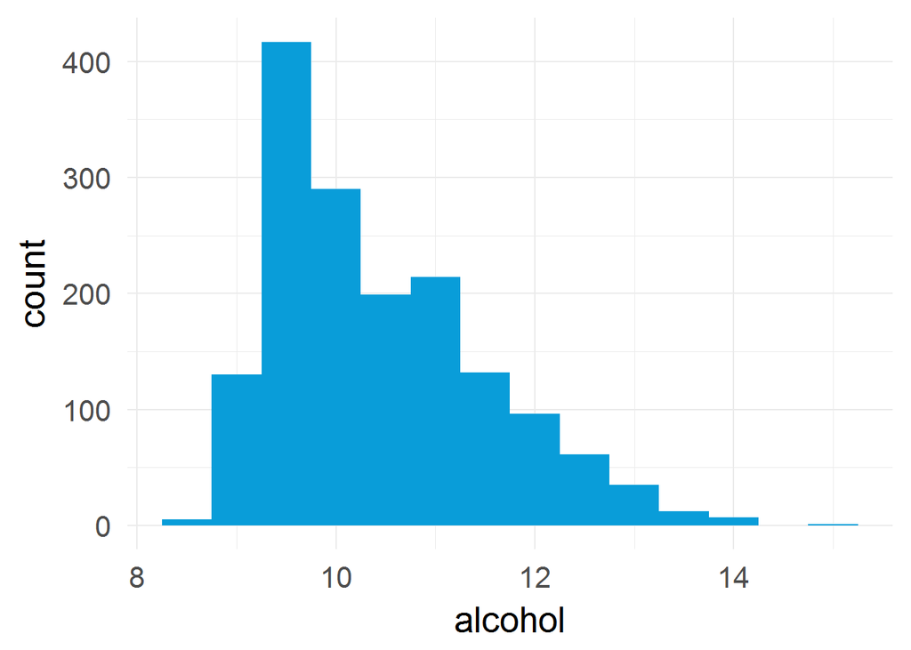

```r
#Histogram of alcohol
qplot(x = alcohol, data=wqr,fill=I('#099DD9'),binwidth=0.5)
```

Alcohol distribution has a peak at 9.5 and is then decreasing until 14.

# Univariate Analysis

### What is/are the main feature(s) of interest in your dataset?

The main feature of interest in this dataset is the wine quality and its variation depending on other chemical criteria. Analyzing which chemical properties constitute higher quality level of wine, will make possible for winemakers to substantially improve their production quality and provide them clear measurable targets in doing so.

### What other features in the dataset do you think will help support your investigation?

All the other chemical properties of the wine and how they are related to each other will certainly help defining what is required to make an excellent wine. A lot of them have a normal distribution. Just looking at them from an univariate point of view is not that meaningful. What will be interesting is to study those quantities, facetting with the quality variable for example, to see how it affects wine quality. We will study this in the Bivariate section.

### Did you create any new variables from existing variables in the dataset?

For sake of readability and ease of use I had to tranform the quality variable as a factor. Except that I did not create any new variable.

### Of the features you investigated, were there any unusual distributions?

The total & free sulfur.dioxyde had a very right long tailed shape. So I changed the scale as a log10 one to transform the distribution from a right long tailed to a normal one. This helped to detect something I was not able to explain: free distribution was not included within total. In some cases, I also had to remove some outliers to get a better view of the overall distribution (residual sugar, chlorides). I noticed also one distribution that does not look like a normal distribution: citric.acid, generally decreasing with 3 peaks.

# Bivariate Plots Section

> **Note**: Before diving into Bi-Variate section I find relevant to get a ggpair set of plots:  
> First, this enables to retrieve some of the results discussed within univariate section, especially those from last “quality” column.  
> Second, it enables to see which couple of Variables are more correlated than others.

[figure not shown]

“Output of ggpairs saved with appropriate resolution”

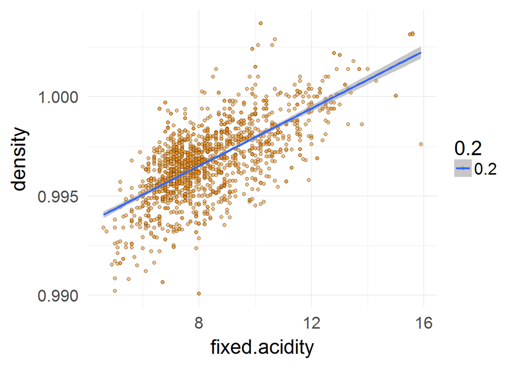

```r
#Plotting density vs fixed.acidity with regression line
ggplot(aes(x=fixed.acidity, y=density, alpha = 0.2), data = wqr) +
  geom_point(fill=I('#F79420'), color=I('black'), shape=21)+
  stat_smooth(method='lm',show.legend=TRUE)
```

As expected, we retrieve here fixed.acidity plotted vs density with regression line displayed. The line fits quite well, with density increasing as fixed.acidity increases and points evenly distributed around the regression line (we can also see a large cluster of points between fixed.acidity 6 & 8).

Let us now investigate a boxplot of pH & Alcohol for each quality.

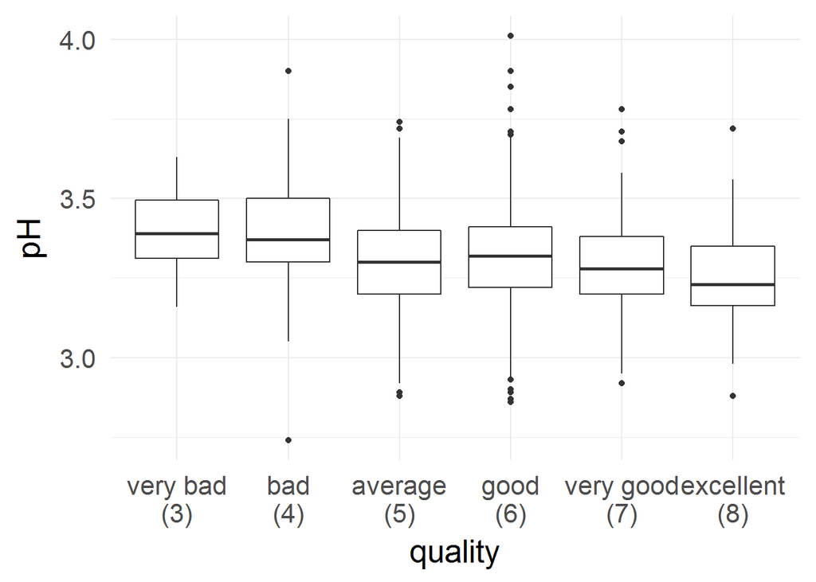

```r
#Boxplot of pH for each quality
qplot(quality,pH, data = wqr, geom = "boxplot")
```

This plot makes a good job at summarizing the data & identifying outliers, and we can almost notice a decreasing pH trend as quality improves when considering median values.  
Let us visualize this trend mor clearly by plotting only the median values.

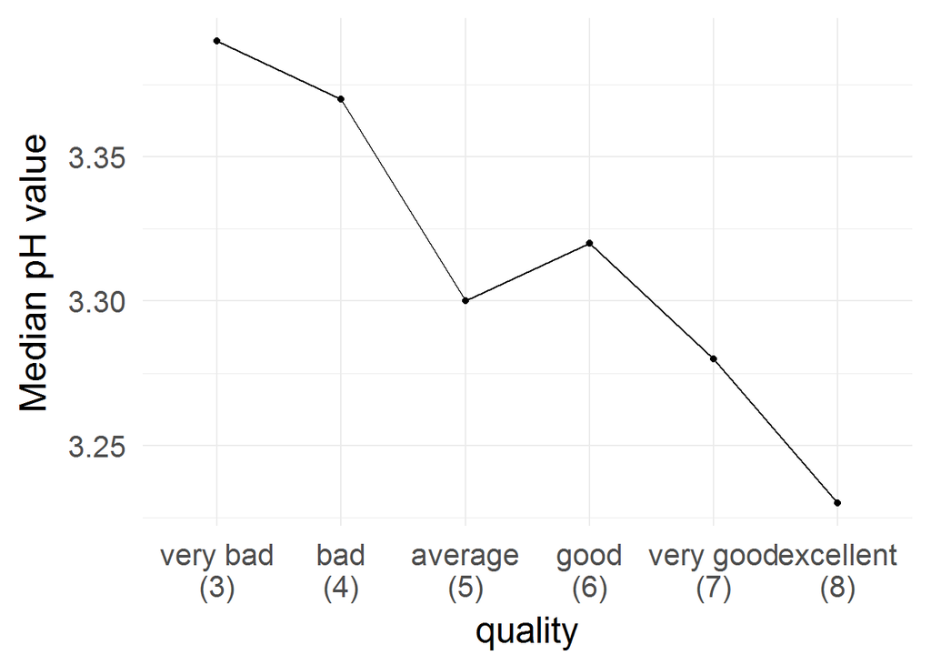

```r
#Building a separate dataframe to hold median values
medianPH<-ddply(wqr,.(quality),summarize,value=median(pH))

#Line plotting the resulting dataframe
ggplot( aes(x = quality, y = value), data = medianPH) +
  geom_point()+
  geom_line(aes(group=1))+
  labs(y="Median pH value")
```

Now, we will do same exercise looking at another variable such as alcohol, first using boxplot, then connecting median values.

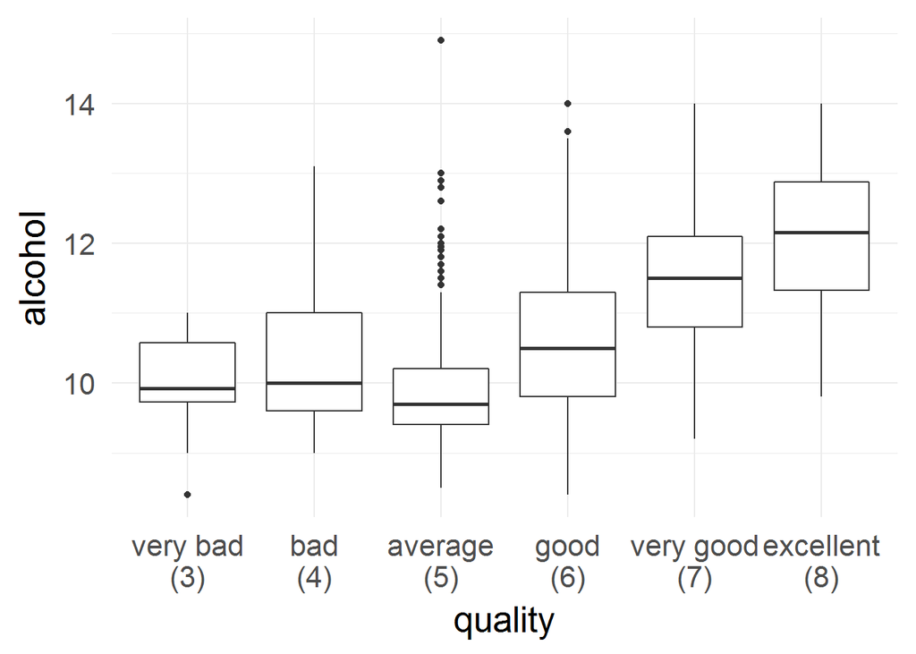

```r
#Boxplot of alcohol for each quality
qplot(quality,alcohol, data = wqr, geom = "boxplot")
```

Again, this plot makes a good job at summarizing the data & identifying outliers, and we can notice a clear increasing alcohol trend as quality improves when considering median values.

Let us visualize this trend mor clearly by plotting only the median values.

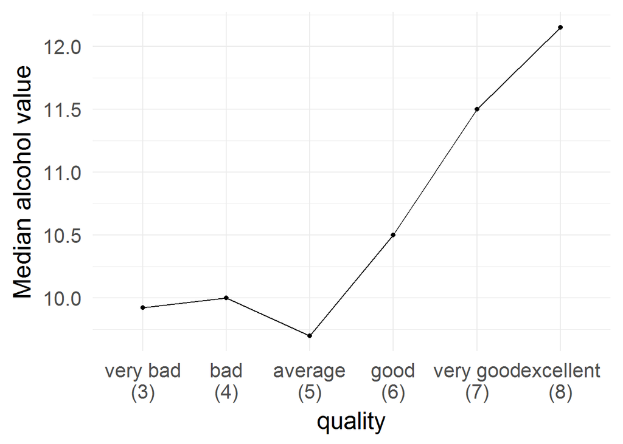

```r
#Building a separate dataframe to hold median values
medianAlcohol<-ddply(wqr,.(quality),summarize,value=median(alcohol))

#Line plotting the resulting dataframe
ggplot( aes(x = quality, y = value), data = medianAlcohol) +
  geom_point()+
  geom_line(aes(group=1))+
  labs(y="Median alcohol value")
```

Here, we want to have a look into single chemical variable distribution per quality. But we do it with some alpha in a way that enables to superimpose many plots at the same time and to ease comparison between them.

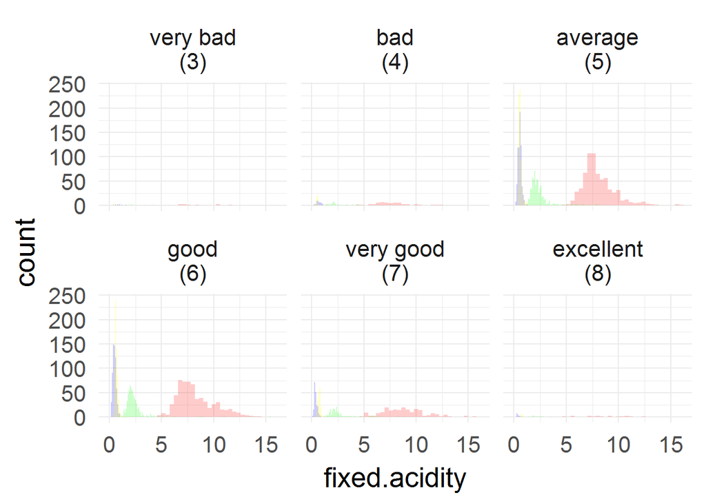

```r
#Grouping by quality and then aggregating multiple histograms with opacity
ggplot(wqr)+
  geom_histogram(aes(x=fixed.acidity),fill='red',alpha=0.2, binwidth=0.4)+
  geom_histogram(aes(x=volatile.acidity),fill='blue',alpha=0.2, binwidth = 0.1)+
  geom_histogram(aes(x=residual.sugar),fill='green',alpha=0.2, binwidth = 0.1)+
  geom_histogram(aes(x=sulphates),fill='yellow',alpha=0.2, binwidth = 0.1)+
  facet_wrap(~quality)
```

Although graphically interesting, I find this plot somehow disappointing in term of information it conveys. It does not bring much to what has already been said within the univariate section and facetting by quality does not enable to find anything particularly interesting: we see normal distribution for medium qualities (average, good , very good) and can’t see any trend for extreme qualities (very bad, excellent) as keeping same scale on all plots does not help in those cases (plots hardly readable).

Below we will apply the same principle, but focusing only on a single variable plot which is sulphates.

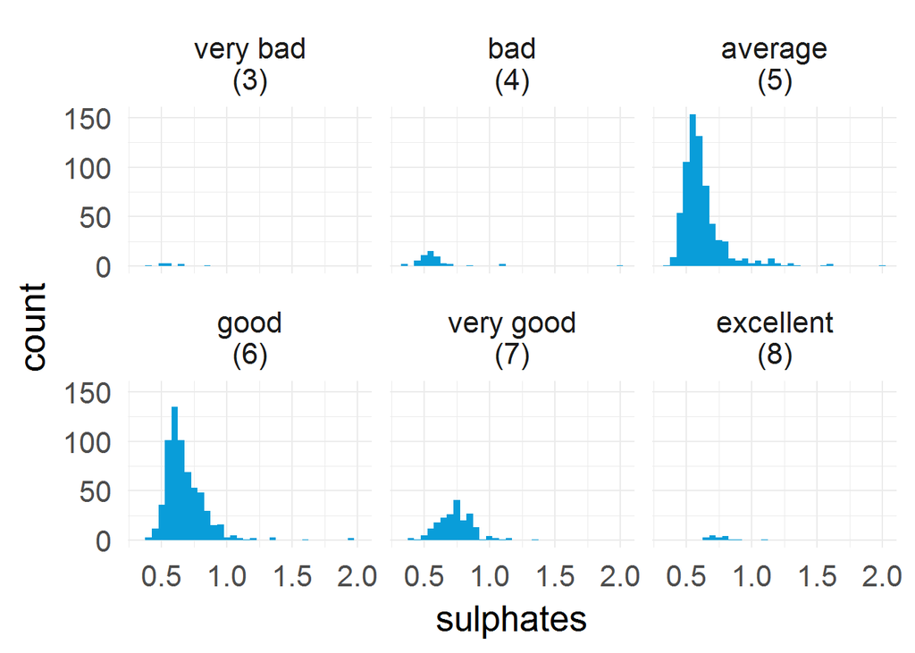

```r
#Group by quality and then sulphates histogram
qplot(x=sulphates,data=wqr,binwidth=0.05,fill=I('#099DD9'))+
  facet_wrap(~quality)
```

Facetting this plot by quality, we can notice that for each plot, the middle of the distribution seems to slightly move on the right. This might indicate that sulphates is increasing as quality improves.

Once again, I choose to plot median sulphates values ordered by increased quality in order to better visualize any trend.

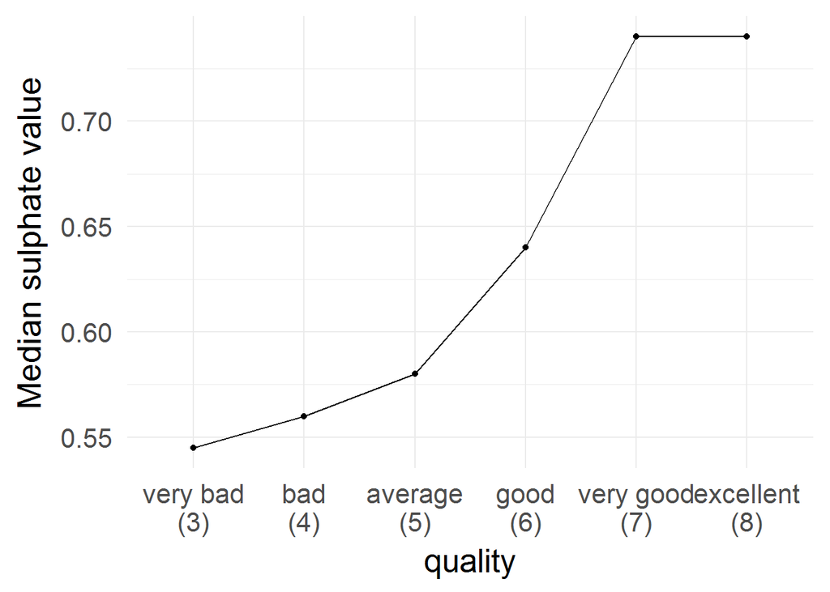

```r
#Building a separate dataframe to hold median values
medianSulphates<-ddply(wqr,.(quality),summarize,value=median(sulphates))

#Line plotting the resulting dataframe
ggplot( aes(x = quality, y = value), data = medianSulphates) +
  geom_point()+
  geom_line(aes(group=1))+
  labs(y="Median sulphate value")
```

This plot verifies the trend which was that sulphates increase as quyality increase, until reaching a plateau. Another way of comparing sulphates distribution depending on quality.

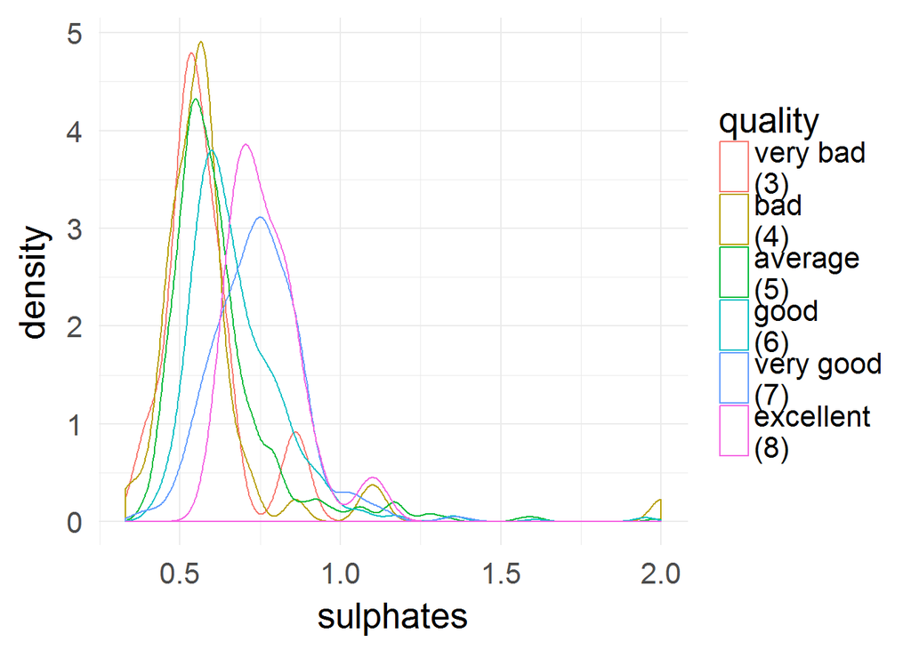

```r
#Density plotting each quality with a different color
ggplot(wqr, aes(sulphates, colour=quality, group=quality)) + geom_density()
```

In this plot, thanks to the colors, we retrieve the major trend (sulphates increase as quality increases) but we also notice some features not observed in other plots (amortized sinusoidal waves for a given quality).

# Bivariate Analysis

### Talk about some of the relationships you observed in this part of the investigation. How did the feature(s) of interest vary with other features in the dataset?

I mostly studied how the chemical properties were affecting the overall quality of the wine. In some cases, I found it useful to build separate variables mostly focusing on median values, which enabled, by ordering the values by quality, to highlight some clear trends in my bivariate analysis:  
- As the quality increases, the median pH seems to drop (almost linearly).  
- As the quality increases, the median alcohol seems to increase (not linearly, a bit like a parabola y= x^2).  
- As the quality increases, the median sulphates seem to increase (not linearly, a bit like a parabola y= x^2) until reaching a plateau.

### Did you observe any interesting relationships between the other features (not the main feature(s) of interest)?

From the density/sulphate plot we can see an amortized oscillation: It could be modeled with a bi-normal distribution, as other oscillations after the two first ones are very small/amortized.